# Prosper Loan Data Exploration

## Introduction

Prosper is a peer-to-peer lending platform for people who might not qualify for bank loans. Prosper bring together low-risk borrowers with willing investors. None of the money you receive as a borrower comes directly from Prosper. Those funds come from investors, who lend you their money. Prosper grades borrowers on a scale of "AA" (the lowest risk) to "HR" (high risk). This Prosper Rating was introduced into the prosper system from July 2009. Prosper has a total of 7 grades with coinciding interest rates charged. You can apply for loans from $2,000 and up to $40,000. Choose from 3- or 5-year terms.

## Preliminary Wrangling

```python
# import all packages and set plots to be embedded inline
import numpy as np
import pandas as pd
import matplotlib.pyplot as plt
import seaborn as sb
pd.set_option('display.max_colwidth',500)

%matplotlib inline
```

```python
#Loading in the orginal dataset
prosper_df = pd.read_csv('prosperLoanData.csv')
prosper_df.head()
```

|  | ListingKey | ListingNumber | ListingCreationDate | CreditGrade | Term | LoanStatus | ClosedDate | BorrowerAPR | BorrowerRate | LenderYield | ... | LP_ServiceFees | LP_CollectionFees | LP_GrossPrincipalLoss | LP_NetPrincipalLoss | LP_NonPrincipalRecoverypayments | PercentFunded | Recommendations | InvestmentFromFriendsCount | InvestmentFromFriendsAmount | Investors |
| --- | --- | --- | --- | --- | --- | --- | --- | --- | --- | --- | --- | --- | --- | --- | --- | --- | --- | --- | --- | --- | --- |
| 0 | 1021339766868145413AB3B | 193129 | 2007-08-26 19:09:29.263000000 | C | 36 | Completed | 2009-08-14 00:00:00 | 0.16516 | 0.1580 | 0.1380 | ... | -133.18 | 0.0 | 0.0 | 0.0 | 0.0 | 1.0 | 0 | 0 | 0.0 | 258 |
| 1 | 10273602499503308B223C1 | 1209647 | 2014-02-27 08:28:07.900000000 | NaN | 36 | Current | NaN | 0.12016 | 0.0920 | 0.0820 | ... | 0.00 | 0.0 | 0.0 | 0.0 | 0.0 | 1.0 | 0 | 0 | 0.0 | 1 |
| 2 | 0EE9337825851032864889A | 81716 | 2007-01-05 15:00:47.090000000 | HR | 36 | Completed | 2009-12-17 00:00:00 | 0.28269 | 0.2750 | 0.2400 | ... | -24.20 | 0.0 | 0.0 | 0.0 | 0.0 | 1.0 | 0 | 0 | 0.0 | 41 |
| 3 | 0EF5356002482715299901A | 658116 | 2012-10-22 11:02:35.010000000 | NaN | 36 | Current | NaN | 0.12528 | 0.0974 | 0.0874 | ... | -108.01 | 0.0 | 0.0 | 0.0 | 0.0 | 1.0 | 0 | 0 | 0.0 | 158 |
| 4 | 0F023589499656230C5E3E2 | 909464 | 2013-09-14 18:38:39.097000000 | NaN | 36 | Current | NaN | 0.24614 | 0.2085 | 0.1985 | ... | -60.27 | 0.0 | 0.0 | 0.0 | 0.0 | 1.0 | 0 | 0 | 0.0 | 20 |

5 rows × 81 columns

```python
prosper_df.info()
```

```
<class 'pandas.core.frame.DataFrame'>
RangeIndex: 113937 entries, 0 to 113936
Data columns (total 81 columns):
 #   Column                               Non-Null Count   Dtype
---  ------                               --------------   -----
 0   ListingKey                           113937 non-null  object
 1   ListingNumber                        113937 non-null  int64
 2   ListingCreationDate                  113937 non-null  object
 3   CreditGrade                          28953 non-null   object
 4   Term                                 113937 non-null  int64
 5   LoanStatus                           113937 non-null  object
 6   ClosedDate                           55089 non-null   object
 7   BorrowerAPR                          113912 non-null  float64
 8   BorrowerRate                         113937 non-null  float64
 9   LenderYield                          113937 non-null  float64
```

[output cut: 73 more lines]

```python
## Columns i'm working with

new_columns = ['LoanKey','ListingCreationDate','LoanStatus','Term','BorrowerRate',
                'ProsperRating (Alpha)','ProsperScore','ListingCategory (numeric)','BorrowerState','EmploymentStatus',
               'Occupation','IsBorrowerHomeowner','DebtToIncomeRatio','IncomeRange','IncomeVerifiable','LoanOriginalAmount',
               'Recommendations']

count= 0

for l in new_columns:
    count+=1

print(count)
```

```
17
```

```python
prosper_df2 = prosper_df[['LoanKey','ListingCreationDate','LoanStatus','Term','BorrowerRate',
                           'ProsperRating (Alpha)','ProsperScore','ListingCategory (numeric)','BorrowerState',
                          'EmploymentStatus','Occupation','IsBorrowerHomeowner','DebtToIncomeRatio','IncomeRange',
                          'IncomeVerifiable','LoanOriginalAmount','Recommendations']]

prosper_df2
```

|  | LoanKey | ListingCreationDate | LoanStatus | Term | BorrowerRate | ProsperRating (Alpha) | ProsperScore | ListingCategory (numeric) | BorrowerState | EmploymentStatus | Occupation | IsBorrowerHomeowner | DebtToIncomeRatio | IncomeRange | IncomeVerifiable | LoanOriginalAmount | Recommendations |
| --- | --- | --- | --- | --- | --- | --- | --- | --- | --- | --- | --- | --- | --- | --- | --- | --- | --- |
| 0 | E33A3400205839220442E84 | 2007-08-26 19:09:29.263000000 | Completed | 36 | 0.1580 | NaN | NaN | 0 | CO | Self-employed | Other | True | 0.17 | $25,000-49,999 | True | 9425 | 0 |
| 1 | 9E3B37071505919926B1D82 | 2014-02-27 08:28:07.900000000 | Current | 36 | 0.0920 | A | 7.0 | 2 | CO | Employed | Professional | False | 0.18 | $50,000-74,999 | True | 10000 | 0 |
| 2 | 6954337960046817851BCB2 | 2007-01-05 15:00:47.090000000 | Completed | 36 | 0.2750 | NaN | NaN | 0 | GA | Not available | Other | False | 0.06 | Not displayed | True | 3001 | 0 |
| 3 | A0393664465886295619C51 | 2012-10-22 11:02:35.010000000 | Current | 36 | 0.0974 | A | 9.0 | 16 | GA | Employed | Skilled Labor | True | 0.15 | $25,000-49,999 | True | 10000 | 0 |
| 4 | A180369302188889200689E | 2013-09-14 18:38:39.097000000 | Current | 36 | 0.2085 | D | 4.0 | 2 | MN | Employed | Executive | True | 0.26 | $100,000+ | True | 15000 | 0 |
| ... | ... | ... | ... | ... | ... | ... | ... | ... | ... | ... | ... | ... | ... | ... | ... | ... | ... |
| 113932 | 9BD7367919051593140DB62 | 2013-04-14 05:55:02.663000000 | Current | 36 | 0.1864 | C | 5.0 | 1 | IL | Employed | Food Service Management | True | 0.13 | $50,000-74,999 | True | 10000 | 0 |
| 113933 | 62D93634569816897D5A276 | 2011-11-03 20:42:55.333000000 | FinalPaymentInProgress | 36 | 0.1110 | A | 8.0 | 7 | PA | Employed | Professional | True | 0.11 | $75,000-99,999 | True | 2000 | 0 |
| 113934 | DD1A370200396006300ACA0 | 2013-12-13 05:49:12.703000000 | Current | 60 | 0.2150 | D | 3.0 | 1 | TX | Employed | Other | True | 0.51 | $25,000-49,999 | True | 10000 | 0 |
| 113935 | 589536350469116027ED11B | 2011-11-14 13:18:26.597000000 | Completed | 60 | 0.2605 | C | 5.0 | 2 | GA | Full-time | Food Service | True | 0.48 | $25,000-49,999 | True | 15000 | 0 |
| 113936 | 00AF3704550953269A64E40 | 2014-01-15 09:27:37.657000000 | Current | 36 | 0.1039 | A | 7.0 | 1 | NY | Employed | Professor | False | 0.23 | $50,000-74,999 | True | 2000 | 0 |

113937 rows × 17 columns

```python
##SAVING THE NEW DATASET CREATED TO A NEW CSV FILE
prosper_df2.to_csv('prosper_loan_data_reviewed.csv', index=False)
```

```python
#Loading in the new dataset
df = pd.read_csv('prosper_loan_data_reviewed.csv')
```

```python
#making a copy of the df to wrangle and analyze
df1 = df.copy()
```

```python
print(df1.info())
```

```
<class 'pandas.core.frame.DataFrame'>
RangeIndex: 113937 entries, 0 to 113936
Data columns (total 17 columns):
 #   Column                     Non-Null Count   Dtype
---  ------                     --------------   -----
 0   LoanKey                    113937 non-null  object
 1   ListingCreationDate        113937 non-null  object
 2   LoanStatus                 113937 non-null  object
 3   Term                       113937 non-null  int64
 4   BorrowerRate               113937 non-null  float64
 5   ProsperRating (Alpha)      84853 non-null   object
 6   ProsperScore               84853 non-null   float64
 7   ListingCategory (numeric)  113937 non-null  int64
 8   BorrowerState              108422 non-null  object
 9   EmploymentStatus           111682 non-null  object
 10  Occupation                 110349 non-null  object
 11  IsBorrowerHomeowner        113937 non-null  bool
 12  DebtToIncomeRatio          105383 non-null  float64
 13  IncomeRange                113937 non-null  object
 14  IncomeVerifiable           113937 non-null  bool
 15  LoanOriginalAmount         113937 non-null  int64
 16  Recommendations            113937 non-null  int64
dtypes: bool(2), float64(3), int64(4), object(8)
memory usage: 13.3+ MB
None
```

```python
#Checking for duplicate values
df1.duplicated().sum()
#No duplicate rows
```

```
0
```

```python
#But there are duplicated loankeys, why is that?
df1['LoanKey'].duplicated().sum()
```

```
871
```

```python
#Checking the duplicated loan key
duplicated_key = df1[df1['LoanKey'].duplicated()]
```

```python
duplicated_key.sample(20)
```

|  | LoanKey | ListingCreationDate | LoanStatus | Term | BorrowerRate | ProsperRating (Alpha) | ProsperScore | ListingCategory (numeric) | BorrowerState | EmploymentStatus | Occupation | IsBorrowerHomeowner | DebtToIncomeRatio | IncomeRange | IncomeVerifiable | LoanOriginalAmount | Recommendations |
| --- | --- | --- | --- | --- | --- | --- | --- | --- | --- | --- | --- | --- | --- | --- | --- | --- | --- |
| 63315 | E85F3705932209564E74FFA | 2013-12-29 10:00:30.213000000 | Current | 36 | 0.0809 | AA | 8.0 | 1 | MD | Employed | Professional | True | 0.20 | $100,000+ | True | 20000 | 0 |
| 50887 | 433F3704669994375948528 | 2014-01-08 12:40:14.030000000 | Current | 36 | 0.1355 | B | 9.0 | 1 | IL | Employed | Professional | False | 0.23 | $100,000+ | True | 18000 | 0 |
| 106320 | 2F393698343279742BBCA3E | 2013-08-24 23:02:37.187000000 | Current | 60 | 0.1520 | B | 4.0 | 1 | NV | Employed | Executive | True | 0.18 | $100,000+ | True | 25000 | 0 |
| 54110 | E7C1369537186202755A234 | 2013-10-01 10:52:20.497000000 | Current | 36 | 0.2999 | HR | 2.0 | 13 | CA | Employed | Sales - Commission | False | 0.16 | $50,000-74,999 | True | 4000 | 0 |
| 75385 | A7A0370149530091696545E | 2013-11-11 20:19:28.227000000 | Current | 36 | 0.2850 | E | 3.0 | 20 | AZ | Employed | Professional | False | 0.14 | $75,000-99,999 | True | 4000 | 0 |
| 60004 | 8D01369797776549074F7AB | 2013-10-22 12:58:24.087000000 | Completed | 36 | 0.1099 | A | 8.0 | 7 | FL | Employed | Other | True | 0.23 | $50,000-74,999 | True | 2000 | 0 |
| 90014 | D3643704360575120ADB3B5 | 2014-01-13 03:44:50.663000000 | Current | 36 | 0.1099 | A | 9.0 | 1 | WA | Employed | Other | True | 0.27 | $100,000+ | True | 35000 | 0 |
| 2539 | DC303708663304668E74587 | 2014-01-11 07:50:08.037000000 | Current | 60 | 0.1224 | B | 10.0 | 1 | NJ | Employed | Police Officer/Correction Officer | True | 0.18 | $100,000+ | True | 35000 | 0 |
| 25083 | 898A3707761826484D8CD8F | 2014-02-18 07:52:40.037000000 | Current | 60 | 0.1435 | B | 9.0 | 7 | TX | Employed | Clerical | True | 0.10 | $50,000-74,999 | True | 15000 | 0 |
| 52300 | F70737035714494792CFCBF | 2014-01-08 11:32:17.687000000 | Current | 36 | 0.0629 | AA | 10.0 | 1 | CA | Employed | Medical Technician | True | 0.24 | $50,000-74,999 | True | 15000 | 0 |
| 106445 | 5C9836954443219487D1CE8 | 2013-10-07 16:15:26.907000000 | Current | 36 | 0.2925 | E | 4.0 | 1 | GA | Employed | Other | True | 0.46 | $1-24,999 | True | 4000 | 0 |
| 71010 | 291C37066927361585B1064 | 2014-02-04 13:07:54.383000000 | Current | 36 | 0.1620 | C | 4.0 | 7 | FL | Employed | Other | True | 0.17 | $75,000-99,999 | True | 7000 | 0 |
| 109067 | 552D3697812282740369CC7 | 2013-10-08 13:21:41.160000000 | Current | 60 | 0.1550 | B | 8.0 | 1 | PA | Employed | Food Service Management | True | 0.27 | $25,000-49,999 | True | 15000 | 0 |
| 79492 | A77936990769582248DB3EB | 2013-09-22 13:23:09.070000000 | Current | 36 | 0.2225 | D | 2.0 | 1 | MD | Employed | Computer Programmer | False | 0.08 | $100,000+ | True | 15000 | 0 |
| 11889 | F456370346258974116F7E5 | 2013-12-09 18:54:29.140000000 | Current | 36 | 0.1239 | A | 5.0 | 1 | FL | Employed | Sales - Retail | True | 0.26 | $25,000-49,999 | True | 8750 | 0 |
| 66698 | BAC037065254951762441DA | 2014-01-06 11:15:40.903000000 | Current | 60 | 0.1099 | A | 6.0 | 1 | TN | Employed | Other | True | 0.21 | $25,000-49,999 | True | 5000 | 0 |
| 104338 | B1243707248995687CC96BB | 2014-02-26 15:00:38.720000000 | Current | 60 | 0.1485 | B | 11.0 | 1 | PA | Employed | Other | False | 0.21 | $100,000+ | True | 25000 | 0 |
| 57269 | 1F1537025243885473899B2 | 2013-12-27 12:25:44.647000000 | Current | 36 | 0.2394 | D | 2.0 | 2 | TX | Employed | Executive | True | 0.16 | $100,000+ | True | 5000 | 0 |
| 84857 | 4BB236991557918388380AA | 2013-10-22 14:27:46.017000000 | Current | 36 | 0.1765 | C | 8.0 | 1 | TX | Other | NaN | False | 0.56 | $50,000-74,999 | True | 15000 | 0 |
| 54876 | A04F3702315882157339CD3 | 2013-10-18 12:53:54.177000000 | Current | 60 | 0.1970 | C | 4.0 | 7 | NM | Employed | Other | True | 0.12 | $25,000-49,999 | True | 2000 | 0 |

```python
#Checking one of the duplicate loankey to see why there is a duplicate
df1[df1['LoanKey'] == '8D84369399064302947D8B5']

#It seems like the only difference between the 2 records is irregularity in prosper score
```

|  | LoanKey | ListingCreationDate | LoanStatus | Term | BorrowerRate | ProsperRating (Alpha) | ProsperScore | ListingCategory (numeric) | BorrowerState | EmploymentStatus | Occupation | IsBorrowerHomeowner | DebtToIncomeRatio | IncomeRange | IncomeVerifiable | LoanOriginalAmount | Recommendations |
| --- | --- | --- | --- | --- | --- | --- | --- | --- | --- | --- | --- | --- | --- | --- | --- | --- | --- |
| 1803 | 8D84369399064302947D8B5 | 2013-09-26 09:35:36.317000000 | Current | 36 | 0.3134 | HR | 3.0 | 7 | MI | Employed | Laborer | True | 0.07 | $50,000-74,999 | True | 4000 | 0 |
| 4942 | 8D84369399064302947D8B5 | 2013-09-26 09:35:36.317000000 | Current | 36 | 0.3134 | HR | 2.0 | 7 | MI | Employed | Laborer | True | 0.07 | $50,000-74,999 | True | 4000 | 0 |

```python
#Checking another duplicate
df1[df1['LoanKey'] == 'C320370672844298400A173']

#It seems like the only difference between the 2 records is irregularity in prosper score
```

|  | LoanKey | ListingCreationDate | LoanStatus | Term | BorrowerRate | ProsperRating (Alpha) | ProsperScore | ListingCategory (numeric) | BorrowerState | EmploymentStatus | Occupation | IsBorrowerHomeowner | DebtToIncomeRatio | IncomeRange | IncomeVerifiable | LoanOriginalAmount | Recommendations |
| --- | --- | --- | --- | --- | --- | --- | --- | --- | --- | --- | --- | --- | --- | --- | --- | --- | --- |
| 85943 | C320370672844298400A173 | 2014-02-06 12:26:43.620000000 | Current | 36 | 0.3059 | HR | 1.0 | 1 | NJ | Employed | Realtor | False | 0.35 | $25,000-49,999 | True | 4000 | 0 |
| 109059 | C320370672844298400A173 | 2014-02-06 12:26:43.620000000 | Current | 36 | 0.3059 | HR | 2.0 | 1 | NJ | Employed | Realtor | False | 0.35 | $25,000-49,999 | True | 4000 | 0 |

```python
#Checking another duplicate
df1[df1['LoanKey'] == '101E37055988584568C9267']

#It seems like the only difference between the 2 records is irregularity in prosper score
```

|  | LoanKey | ListingCreationDate | LoanStatus | Term | BorrowerRate | ProsperRating (Alpha) | ProsperScore | ListingCategory (numeric) | BorrowerState | EmploymentStatus | Occupation | IsBorrowerHomeowner | DebtToIncomeRatio | IncomeRange | IncomeVerifiable | LoanOriginalAmount | Recommendations |
| --- | --- | --- | --- | --- | --- | --- | --- | --- | --- | --- | --- | --- | --- | --- | --- | --- | --- |
| 25497 | 101E37055988584568C9267 | 2013-11-04 17:04:59.543000000 | Current | 60 | 0.1905 | C | 7.0 | 1 | FL | Employed | Professional | False | 0.46 | $50,000-74,999 | True | 15000 | 0 |
| 25498 | 101E37055988584568C9267 | 2013-11-04 17:04:59.543000000 | Current | 60 | 0.1905 | C | 8.0 | 1 | FL | Employed | Professional | False | 0.46 | $50,000-74,999 | True | 15000 | 0 |

```python
#Checking another duplicate
df1[df1['LoanKey'] == 'F3AB369770667777597274C' ]
```

|  | LoanKey | ListingCreationDate | LoanStatus | Term | BorrowerRate | ProsperRating (Alpha) | ProsperScore | ListingCategory (numeric) | BorrowerState | EmploymentStatus | Occupation | IsBorrowerHomeowner | DebtToIncomeRatio | IncomeRange | IncomeVerifiable | LoanOriginalAmount | Recommendations |
| --- | --- | --- | --- | --- | --- | --- | --- | --- | --- | --- | --- | --- | --- | --- | --- | --- | --- |
| 8533 | F3AB369770667777597274C | 2013-11-07 14:26:31.317000000 | Current | 60 | 0.1819 | B | 7.0 | 1 | WI | Employed | Skilled Labor | False | 0.42 | $50,000-74,999 | True | 10000 | 0 |
| 113733 | F3AB369770667777597274C | 2013-11-07 14:26:31.317000000 | Current | 60 | 0.1819 | B | 8.0 | 1 | WI | Employed | Skilled Labor | False | 0.42 | $50,000-74,999 | True | 10000 | 0 |

```python
#Checking another duplicate
df1[df1['LoanKey'] == 'F3AB369770667777597274C' ]
```

|  | LoanKey | ListingCreationDate | LoanStatus | Term | BorrowerRate | ProsperRating (Alpha) | ProsperScore | ListingCategory (numeric) | BorrowerState | EmploymentStatus | Occupation | IsBorrowerHomeowner | DebtToIncomeRatio | IncomeRange | IncomeVerifiable | LoanOriginalAmount | Recommendations |
| --- | --- | --- | --- | --- | --- | --- | --- | --- | --- | --- | --- | --- | --- | --- | --- | --- | --- |
| 8533 | F3AB369770667777597274C | 2013-11-07 14:26:31.317000000 | Current | 60 | 0.1819 | B | 7.0 | 1 | WI | Employed | Skilled Labor | False | 0.42 | $50,000-74,999 | True | 10000 | 0 |
| 113733 | F3AB369770667777597274C | 2013-11-07 14:26:31.317000000 | Current | 60 | 0.1819 | B | 8.0 | 1 | WI | Employed | Skilled Labor | False | 0.42 | $50,000-74,999 | True | 10000 | 0 |

```python
#Dropping ProsperScore column and deciding to stick to the ProsperRating for analysis
df1.drop('ProsperScore',axis=1,inplace=True)
```

```python
#Now that ProsperScore column has been dropped, we see that there are duplicate records
df1.duplicated().sum()
```

```
871
```

```python
#Dropping duplicate records
df1.drop_duplicates(inplace=True)
```

```python
#confirming they have been dropped
df1.duplicated().sum()
```

```
0
```

```python
df1.info()
```

```
<class 'pandas.core.frame.DataFrame'>
Int64Index: 113066 entries, 0 to 113936
Data columns (total 16 columns):
 #   Column                     Non-Null Count   Dtype
---  ------                     --------------   -----
 0   LoanKey                    113066 non-null  object
 1   ListingCreationDate        113066 non-null  object
 2   LoanStatus                 113066 non-null  object
 3   Term                       113066 non-null  int64
 4   BorrowerRate               113066 non-null  float64
 5   ProsperRating (Alpha)      83982 non-null   object
 6   ListingCategory (numeric)  113066 non-null  int64
 7   BorrowerState              107551 non-null  object
 8   EmploymentStatus           110811 non-null  object
 9   Occupation                 109537 non-null  object
 10  IsBorrowerHomeowner        113066 non-null  bool
 11  DebtToIncomeRatio          104594 non-null  float64
 12  IncomeRange                113066 non-null  object
 13  IncomeVerifiable           113066 non-null  bool
 14  LoanOriginalAmount         113066 non-null  int64
 15  Recommendations            113066 non-null  int64
dtypes: bool(2), float64(2), int64(4), object(8)
memory usage: 13.2+ MB
```

## Converting columns to their appropriate datatypes

### Converting columns ProsperRating (Alpha) and IncomeRange to Categorical Datatype

#### Convert the "ProsperRating (Alpha)" column from a plain object type into an ordered categorical type

The Prosper Rating system consists of seven grades: AA-7, A-6, B-5, C-4, D-3, E-2 and HR-1 corresponding to lowest to highest credit risk. With HR being High Risk and AA being lowest risk

Arranging the income range in ascending order

```python
# Convert the "ProsperRating (Alpha)" column from a plain object type into an ordered categorical type
rating_order = ['AA','A','B','C','D','E','HR']
rating_category = pd.api.types.CategoricalDtype(ordered=True, categories=rating_order)

df1['ProsperRating (Alpha)'] = df1['ProsperRating (Alpha)'].astype(rating_category)



#Arranging the income range in ascending order
income_range_order = ['Not displayed','Not employed','$0','$1-24,999','$25,000-49,999','$50,000-74,999'
                        ,'$75,000-99,999','$100,000+']
income_range_category = pd.api.types.CategoricalDtype(ordered=True, categories=income_range_order)
df1['IncomeRange'] = df1['IncomeRange'].astype(income_range_category)




#The LoanStatus has a lot of past dues, so I created a new column to convert them all into single past due
df1['LoanStatusReviewed'] =df1['LoanStatus'].apply(lambda x : x.split('(')[0])

#Arranging the status in the below order
status_order = ['Completed','Current','FinalPaymentInProgress', 'Past Due','Defaulted','Chargedoff','Cancelled']
status_category = pd.api.types.CategoricalDtype(ordered=True, categories=status_order)

df1['LoanStatusReviewed'] = df1['LoanStatusReviewed'].astype(status_category)
```

```python
## FUNCTIONS
```

```python
#Defining a functon for x and y-axis titles
def labels(xlabel,ylabel):
    '''Gives titles to
       x-axis and y-axis
    '''
    plt.xlabel(xlabel)
    plt.ylabel(ylabel)


#Writing a function to rotate xticks on facetgrid
def xtick_rot():
    '''
    Rotates the x-axis
    function of each facet
    on a FacetGrid
    '''
    for ax in g.axes.flat:
        for label in ax.get_xticklabels():
            label.set_rotation(90)


#A function to label the y ticks as proprpotions for loan statuses
def prop_for_loan_status(dataframe,title):
    status_count = dataframe['LoanStatusReviewed'].value_counts()
    status_sum = status_count.sum()
    status_order = status_count.index
    max_status_prop = status_count[0]/status_sum
    tick_prop = np.arange(0,max_status_prop+0.05,0.05)
    tick_names = ['{:0.2f}'.format(v) for v in tick_prop]
    sb.countplot(data=dataframe,x='LoanStatusReviewed', order=status_order,color=color)
    plt.yticks(ticks=tick_prop * status_sum, labels=tick_names)  #to set the current tick locations and labels of the x-axis
    plt.ylabel('proportion')
    plt.xticks(rotation=90)
    plt.title(title);
```

#### Description of the function prop_for_loan_status

# First I got a count of each unique loan status using value_counts()

status_count = df1['LoanStatusReviewed'].value_counts()

# Then I got the total sum of all the values

status_sum = status_count.sum()

# I got the index i.e the unique loan status in orderd o decreasing frequency

status_order = status_count.index

# Then I got my maximum proportion so I could use it to determine the ticks and maximum tick

max_status_prop = status_count[0]/status_sum

# Then created a range of values for my tickx in steps of 0.05

tick_prop = np.arange(0,max_status_prop+0.05,0.05)

# I created a list of my ticknames from the tick_props whlst formatting it to 2 decimal places

tick_names = ['{:0.2f}'.format(v) for v in tick_prop]

```python
##Converting column ListingCreationDate to a datetime datatype
df1['ListingCreationDate'] = pd.to_datetime(df1['ListingCreationDate'])
```

```python
df1.info()
```

```
<class 'pandas.core.frame.DataFrame'>
Int64Index: 113066 entries, 0 to 113936
Data columns (total 17 columns):
 #   Column                     Non-Null Count   Dtype
---  ------                     --------------   -----
 0   LoanKey                    113066 non-null  object
 1   ListingCreationDate        113066 non-null  datetime64[ns]
 2   LoanStatus                 113066 non-null  object
 3   Term                       113066 non-null  int64
 4   BorrowerRate               113066 non-null  float64
 5   ProsperRating (Alpha)      83982 non-null   category
 6   ListingCategory (numeric)  113066 non-null  int64
 7   BorrowerState              107551 non-null  object
 8   EmploymentStatus           110811 non-null  object
 9   Occupation                 109537 non-null  object
 10  IsBorrowerHomeowner        113066 non-null  bool
 11  DebtToIncomeRatio          104594 non-null  float64
 12  IncomeRange                113066 non-null  category
 13  IncomeVerifiable           113066 non-null  bool
 14  LoanOriginalAmount         113066 non-null  int64
 15  Recommendations            113066 non-null  int64
 16  LoanStatusReviewed         111009 non-null  category
dtypes: bool(2), category(3), datetime64[ns](1), float64(2), int64(4), object(5)
memory usage: 11.8+ MB
```

### What is the structure of your dataset?

> There are 113,066 rows in this dataset with 17 columns

### What features in the dataset do you think will help support your investigation into your feature(s) of interest?

> Term, Profession, IsBorrowerHomeOwner, LoanOriginalAmount, debt to income ratio

## Looking at my 2 main features of interest i.e. LoanStatus and ProsperRating

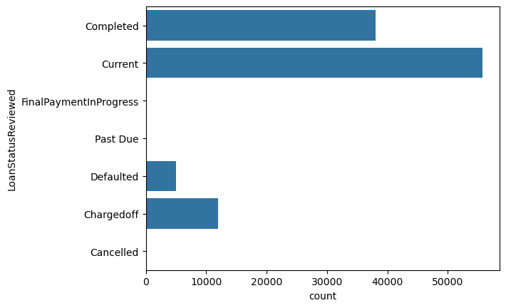

```python
# 1. What are the different loan status and their frequency

color = sb.color_palette()[0]
sb.countplot(data=df1,y='LoanStatusReviewed', color=color);

#Most of the loans are current or have been completed
#Although a significant amount of loans were chargedoff and defaulted
```

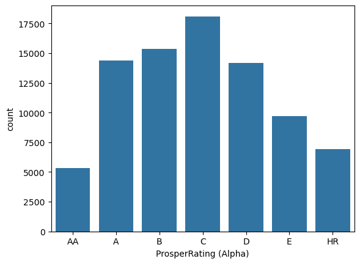

```python
# 2.  Determing the frequency of the different ratings

sb.countplot(data=df1,x='ProsperRating (Alpha)', color=color);

#An Average rating of C has the highest frequency
#A significnat number of borrowers were high risk, wha makes them hgh risk?,debttoincomeratio,employmentstatus,incomerange,
#incomeverifiable
#wHAT are there terms,loanoriginalamount,borrowerrate
```

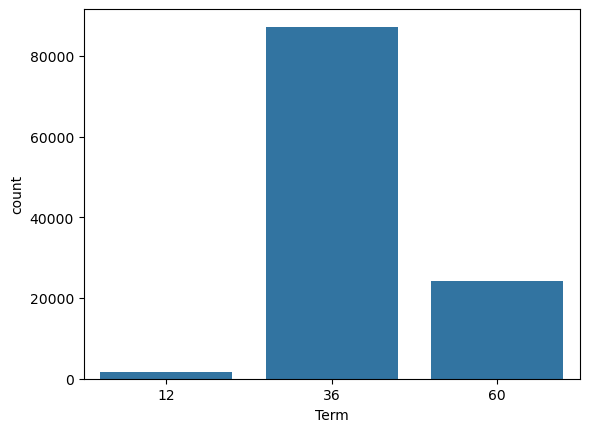

```python
# 3. How long were most loan given?

sb.countplot(data=df1,x='Term',color=color);

#most terms were 36 months
```

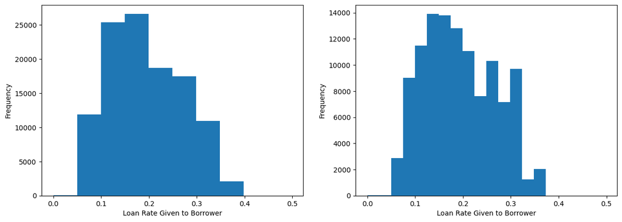

```python
## 4. The Distribution of the Loan Rates
plt.figure(figsize=[15,5])

plt.subplot(1,2,1)
plt.hist(data=df1,x='BorrowerRate')
labels('Loan Rate Given to Borrower','Frequency');
#Most rates were between 0.1 t0 0.2
#Is this a standard rate or does it depend on the term or loan amount or the risk


plt.subplot(1,2,2)
plt.hist(data=df1,x='BorrowerRate',bins=20)
labels('Loan Rate Given to Borrower','Frequency');
```

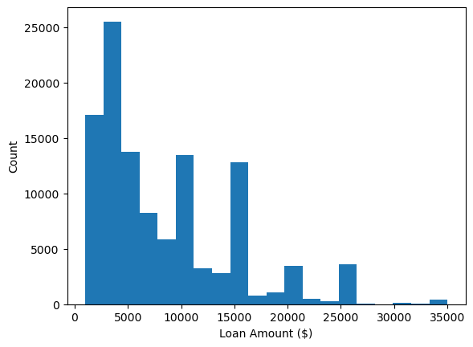

```python
# 5. Distribution of Loan Amount
plt.hist(data=df1,x='LoanOriginalAmount',bins=20)
labels('Loan Amount ($)','Count');
#Most of the loans given are in the range of 5000
#Did the Loan Amount determine the term and rate
```

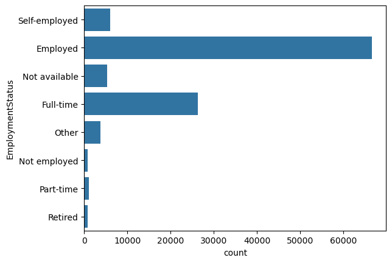

```python
# 6. What is the employment status of most people that took the laon
sb.countplot(data=df1,y='EmploymentStatus',color=color);
#plt.xticks(rotation=30)

#The highest number of people prosper gives loans to employed people
```

### 7. Does prosper give out loans based on your income

Plotting a bar chart of their frequencies

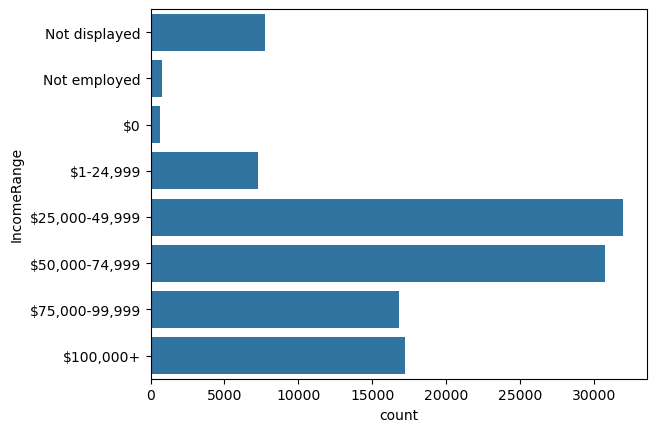

```python
sb.countplot(data=df1,y='IncomeRange',color=color);
#It can be seen that Prosper gives loans mostly to people with income range from 25,000 and above
#What terms,rating and status do these people hvae
```

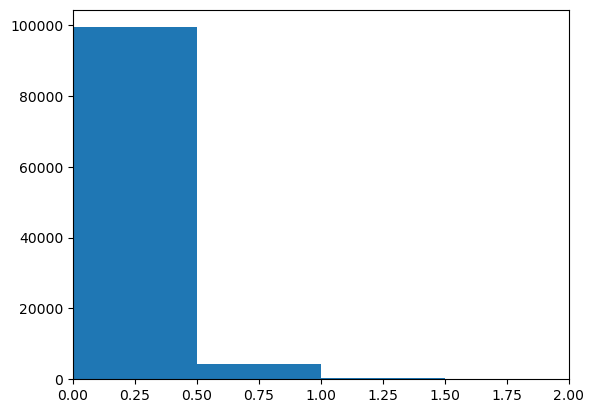

```python
# 8. Distribution of DebtToIncomeRatio
plt.hist(data=df1,x='DebtToIncomeRatio',bins=20)
plt.xlim(0,2);

#Borrowers have low debt to income ration, mostly between 0 and 1
```

### 9. what reason did people takeout loan for?

ListingCategory The category of the listing that the borrower selected when posting their listing: 0 - Not Available, 1 - Debt Consolidation, 2 - Home Improvement, 3 - Business, 4 - Personal Loan, 5 - Student Use, 6 - Auto, 7- Other, 8 - Baby&Adoption, 9 - Boat, 10 - Cosmetic Procedure, 11 - Engagement Ring, 12 - Green Loans, 13 - Household Expenses, 14 - Large Purchases, 15 - Medical/Dental, 16 - Motorcycle, 17 - RV, 18 - Taxes, 19 - Vacation, 20 - Wedding Loans

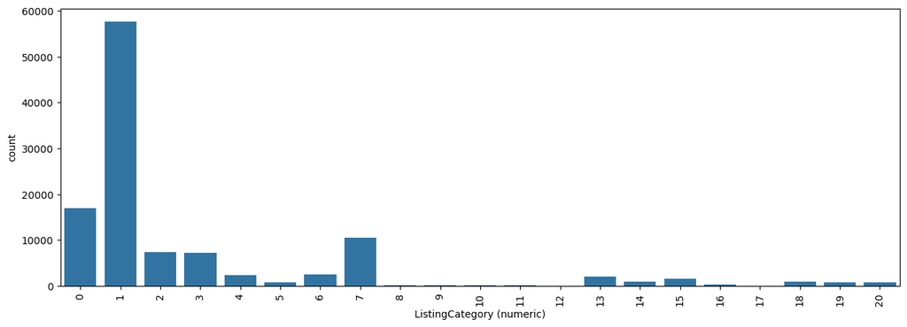

```python
#df1['ListingCategory (numeric)'].value_counts()
plt.figure(figsize=[15,5])
sb.countplot(data=df1,x='ListingCategory (numeric)',color=color)
plt.xticks(rotation=90);

##most loans were taken out as debt consolidation
## The next 2 reasons people took out loans for were 'other(7)' and 'not available(0)'
## A good number of people also took out loans for business(3) and home improvement(2)
#how many of these people actually are current with their loan
```

> **Rubric Tip**: Visualizations should depict the data appropriately so that the plots are easily interpretable. You should choose an appropriate plot type, data encodings, and formatting as needed. The formatting may include setting/adding the title, labels, legend, and comments. Also, do not overplot or incorrectly plot ordinal data.

### Observations From Univariate Visuals

1. Majority of the loans were completed and current but there were still significant loans that were defaulted and charged off More info: What terms do the differnt loan status fall into

   ```
       Compare with IncomeRange, LoanOrignalAmount and Rating
   ```

## Bivariate Exploration

### 1. From Observation 1

- What terms do the differnt loan status fall into
- Comparing the different LoanStatus to the Income Range
- Seeing the Distribution of loan amount for each loan status
- Comparing LoanStatus to PRosperRating

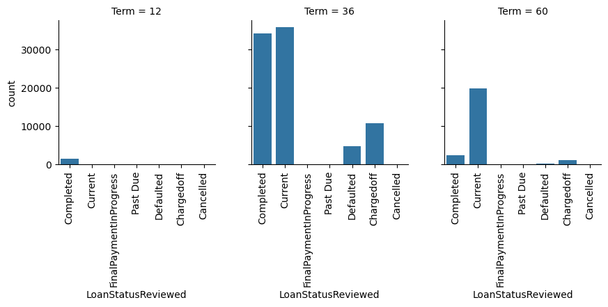

```python
##Comparng Loan Status of different terms
g = sb.FacetGrid(data=df1,col='Term')
g.map(sb.countplot,'LoanStatusReviewed')
xtick_rot()

#Borrowers witth 12 and 60 months hardly defaulted but a significant amount of borrowers with a term of
#60 months were charged off
#For 36 months, a lot were defaulted and charged off not withstanding a greater number are current
#and have completed their loans
```

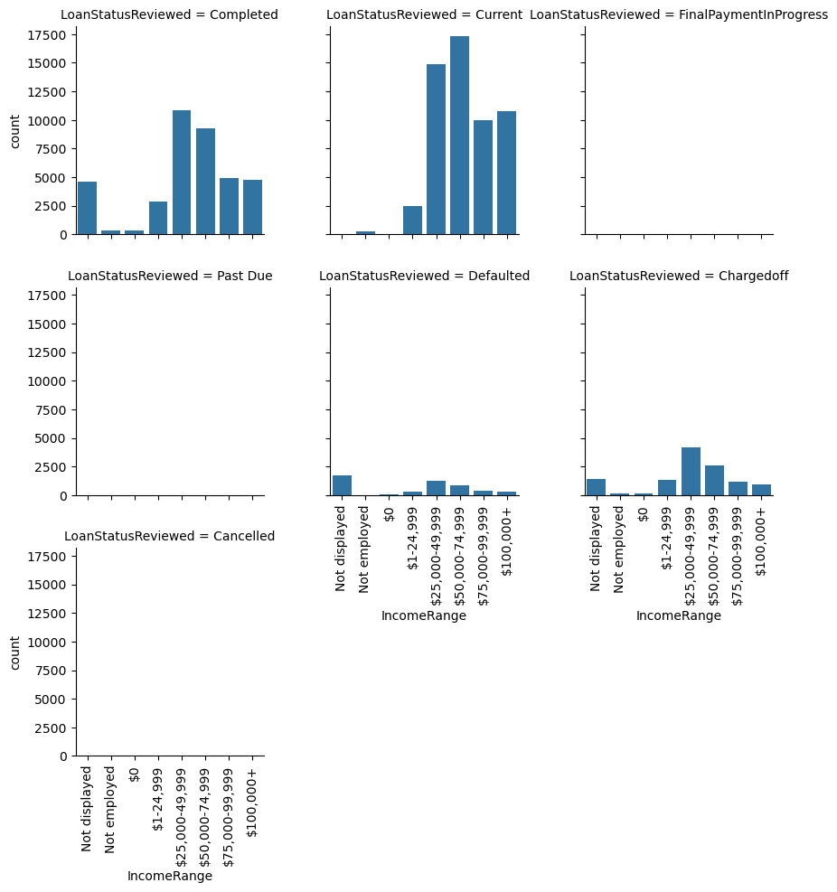

```python
# Comparing IncomeRange of each Loan Status
g = sb.FacetGrid(data=df1,col='LoanStatusReviewed',col_wrap=3)
g.map(sb.countplot,'IncomeRange')

xtick_rot()

#As most of the borrowers invthe prosper dataset have an income of 25,000 dollars , a lot of their loans were completed or are
#current but still a significant number was either charged off or defaulted
```

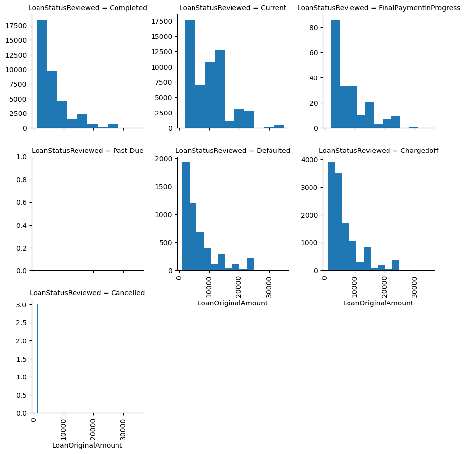

```python
##Seeing the Distribution of loan amount for each loan status
g = sb.FacetGrid(data=df1,col='LoanStatusReviewed',col_wrap=3,sharey=False)
g.map(plt.hist,'LoanOriginalAmount')

xtick_rot()

#Most Loan amounts that were charged off or defaulted were less than 5000 dollars
#All other loan statuses had their mosg frequent loan amount as around 5,000
```

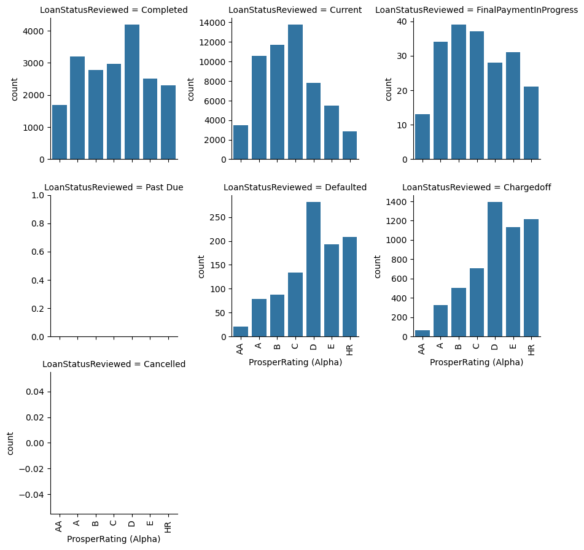

```python
## Comparing LoanStatus to ProsperRating

g = sb.FacetGrid(data=df1,col='LoanStatusReviewed',col_wrap=3,sharey=False)
g.map(sb.countplot,'ProsperRating (Alpha)')

xtick_rot()

#Defaulted and charged off loans have a higher rating of D,E, and HR in comparison to the other ratings
#For completed loan status, the highest had a rating of 'D'
```

### 2. From Observation 2

- Comparing Ratings of High Risk to BorrowerRate,DebtToIncomeRation,Term and LoanOriginalAmount

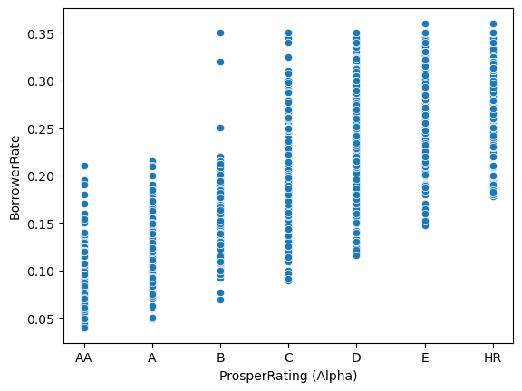

```python
#Relationship between rating and borrower's rate

sb.scatterplot(data=df1, x='ProsperRating (Alpha)', y='BorrowerRate');

#the higher the risk, the higher the rate
#Borrower's that are high risk have a higher rate
```

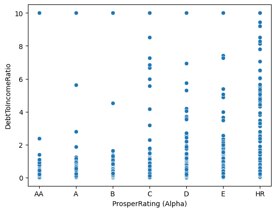

```python
#Relationship between rating and DebtToIncomeRatio
sb.scatterplot(data=df1, x='ProsperRating (Alpha)', y='DebtToIncomeRatio');
#More Borrowerss in High Risk have higher Debt To Income Ratio
```

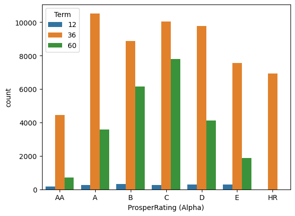

```python
#Comparing Rating with Term
sb.countplot(data=df1,x='ProsperRating (Alpha)',hue='Term' );

#36 months terms have the highest frequency in all ratings, this is probably due to the fact that most loans are 36 months
#
```

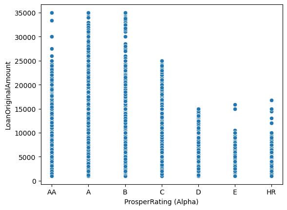

```python
#Relationship between rating and LoanOriginalAmount
sb.scatterplot(data=df1, x='ProsperRating (Alpha)', y='LoanOriginalAmount') ;
#Lower Risks Rating have high loan amount
#High Risk Rating have a maximum of about 17,000 dollar
```

## 3. From Observation 3 : Majority of Borrowers were 36 months

Comparing Term with Borrower's rate,LoanOriginalAmount

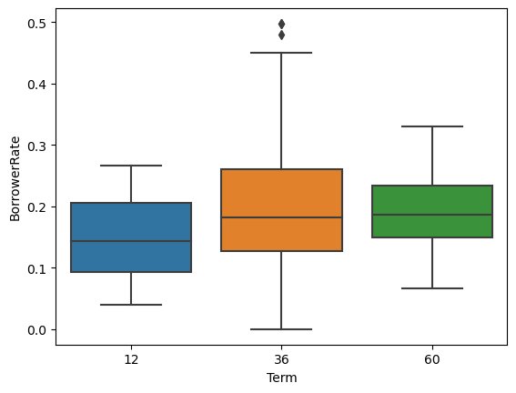

```python
#Comparing Term with Borrower's rate
sb.boxplot(data=df1,y='BorrowerRate',x='Term');

#36 months term has a higher maximum rate and a generally higher rate. This can be attributed to its frequency in the data
#But when we look at the median of each term, 60 month terms have the highest median,followed closely by the 36 months, then
#the 12 month
```

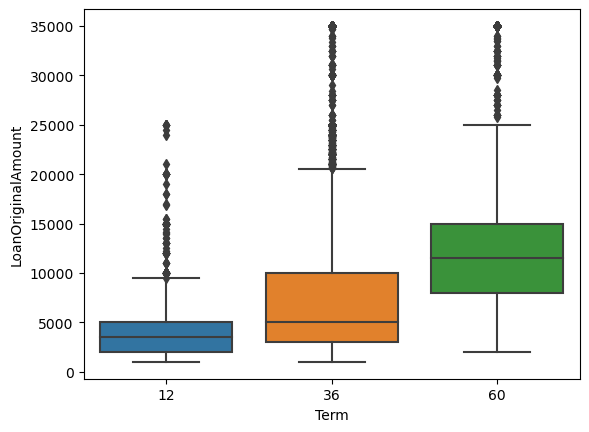

```python
#Comparing Term with LoanOriginalAmount
sb.boxplot(data=df1,x='Term',y='LoanOriginalAmount');

#60 month terms have the highest Loan amounts, followed by 36 and then 12.
#there is a large amount of outliers with each month.
```

### 4. Observation 4: Most of the Borrower's Rate were bt0.1 t0 0.2

-Do high Borrower's Rate mean High LOan Original Amount?

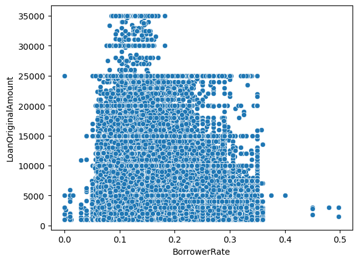

```python
#-Do high Borrower's Rate mean High LOan Original Amount?

sb.scatterplot(data=df1,x='BorrowerRate',y='LoanOriginalAmount')

#Not necessarily, higher loan amount are seen to majorly fall between rates of 0.05 and 0.2 i.e 5% to 20%
```

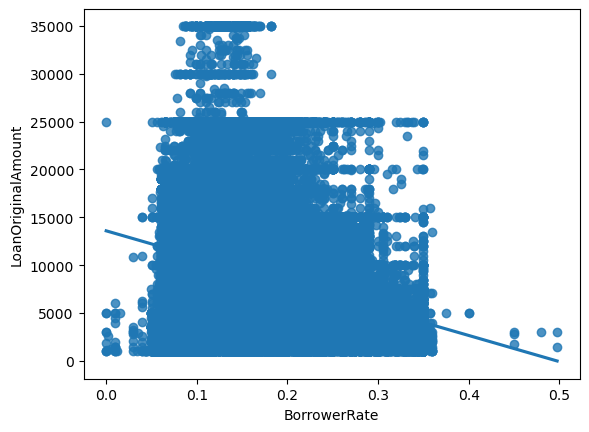

```python
sb.regplot(data=df1,x='BorrowerRate',y='LoanOriginalAmount',truncate=True)
```

### 5. Observation 6

--Comparing LoanStatus of each Employment Status Getting the proportion of Loan Statuses for each Employment Stattus

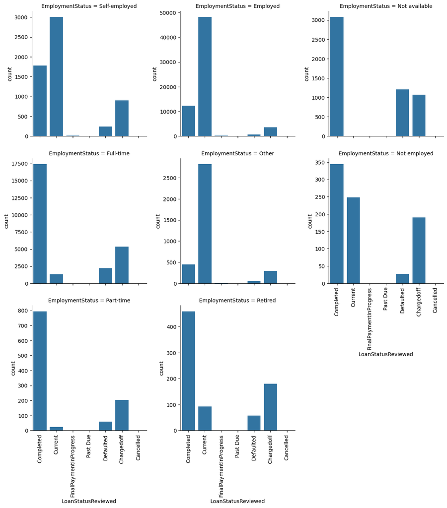

```python
#Comparing LoanStatus of each Employment Status
g = sb.FacetGrid(data=df1, col='EmploymentStatus',col_wrap= 3,height=4,sharey=False)
g.map(sb.countplot,'LoanStatusReviewed');

xtick_rot()

#Unemployed or not, most of theri loans were either completed or current
#For Retired, the ratio of charged off to completed is 195:450 i.e. 1:2
#Tor one person that gets charged off 2 people complete their loans
```

#### Comparing LoanStatus of each Employment Status in proportions

```python
#Creating the proportion value
status_count = df1['LoanStatusReviewed'].value_counts()
status_sum = status_count.sum()
status_order = status_count.index
max_status_prop = status_count[0]/status_sum
tick_prop = np.arange(0,max_status_prop+0.05,0.05)


tick_names = ['{:0.2f}'.format(v) for v in tick_prop]
```

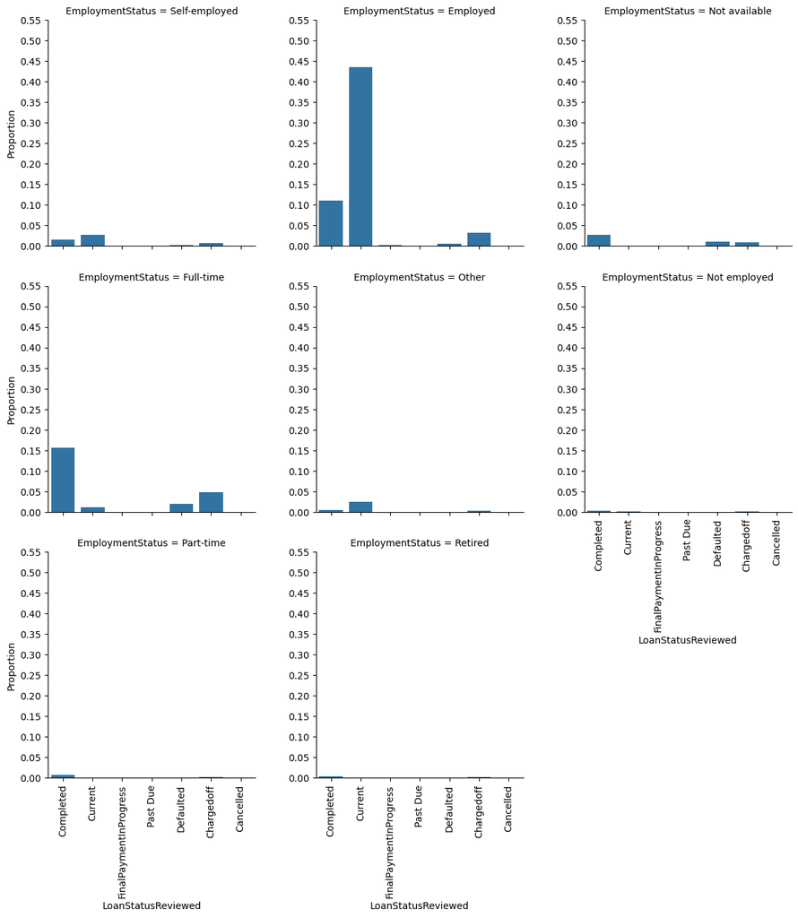

```python
#Comparing LoanStatus of each Employment Status in proportions
g = sb.FacetGrid(data=df1, col='EmploymentStatus',col_wrap= 3,height=4,sharey=False)
g.map(sb.countplot,'LoanStatusReviewed');
g.set(yticks=tick_prop * status_sum) #to set tick location on the yaxis
g.set_yticklabels(tick_names) #to set tick label on the y-axisv
g.set_ylabels('Proportion')

xtick_rot()
```

## 6. Observation 7 Most Borrowers have an income of 25,000 and above

--What is their rating and loan status

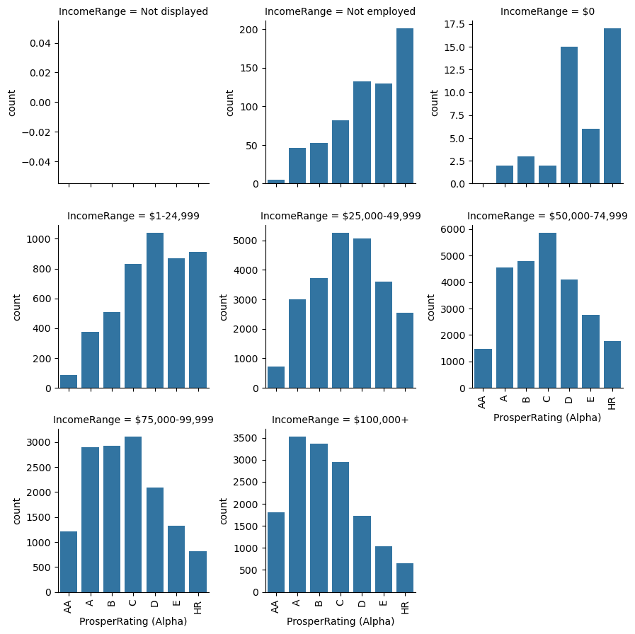

```python
#Comparing income range with rating
g = sb.FacetGrid(data=df1,col='IncomeRange',col_wrap=3,sharey=False)
g.map(sb.countplot,'ProsperRating (Alpha)')
xtick_rot()

#People with higher income range are generally of lower risks
#People in the range of 1-24,999 dollars have a significant amount of high risk compared to other ratings
#Those in the income range 50000 - 74,999 defaulted a lot of payments. 75000+ have low defaults
```

## 7. Observation 8 : Most Borrowers have low DebtToIncomeRatio

--Compare with Borrower Rate

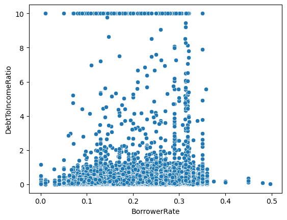

```python
sb.scatterplot(data=df1,x='BorrowerRate',y='DebtToIncomeRatio')
```

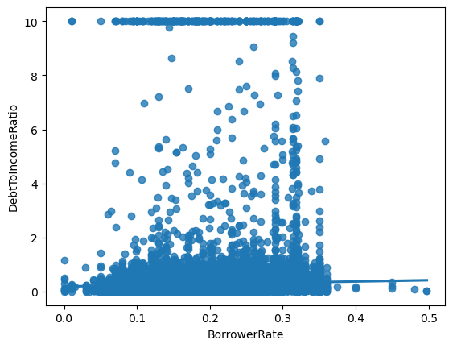

```python
sb.regplot(data=df1,x='BorrowerRate',y='DebtToIncomeRatio')
```

While most borrowers have their rate in the range of 0.05 to 0.35 and DTIR of between 0 to 2. People who have a high DTIR have a rate of 0.2 to 0.35. There is not exactly a direct relationship between DTIR and Rate. There a few outliers on Borrower from about 0.36 to 0.5 which have very low DTIR. The outlier of DTIR of 10 is spread from 0.05 to 0.35

### 8. Observation 9: Most People took out loan for debt consolidation(Listing Category)

-- Compare with loan status 1 = Debt Consolidation 2 = Home Improvement 3 = Borrower

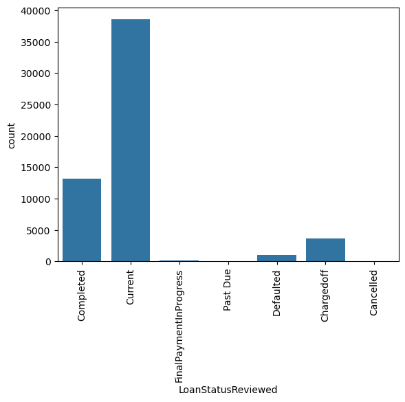

```python
#LoanStatus for Borrowers who took a loan because of Debt Consolidation

#Created a dataframe for Borrowers with only Debt Consolidation as their reason
reason_for_loan_sub = df1.loc[df1['ListingCategory (numeric)'].isin([1])]

#Plotting a barchart of their LoanStatus
sb.countplot(data=reason_for_loan_sub,x='LoanStatusReviewed',color=color)
plt.xticks(rotation=90);
```

```python
### I decdied to compare debt consolidation with the reasons which followed it in frequency
## They are Home mprovement and Business which are labelled 2 and 3 respectively
### There is a largin margin in terms of frequency between debt consolidation and these 2
### But I just want to compare their loan status
```

```python
order = ['Completed','Current','FinalPaymentInProgress', 'Past Due','Defaulted','Chargedoff']
```

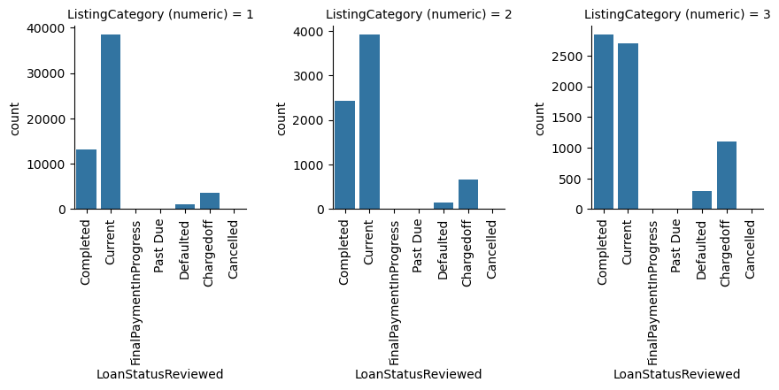

```python
reason_for_loan_subs = df1.loc[df1['ListingCategory (numeric)'].isin([1,2,3])]
g = sb.FacetGrid(data=reason_for_loan_subs, col='ListingCategory (numeric)',sharey=False)
g.map(sb.countplot,'LoanStatusReviewed')
xtick_rot()
```

Business had more charged off and defaulted in proportion to the other 2 reasons

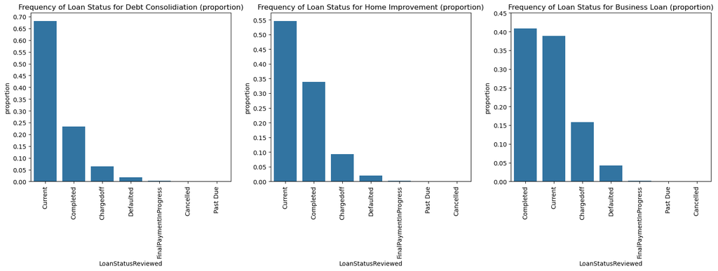

```python
##To get a prorporting of the loan statuses for each of 3 reasons wht the loan was taken
#those reasons include Debt Consolidation, home improvement and business loan

#first we create a dataframe that only includes them
debt_cons_loan = df1[df1['ListingCategory (numeric)'] == 1]
home_improv_loan = df1[df1['ListingCategory (numeric)'] == 2]
bus_loan = df1[df1['ListingCategory (numeric)'] == 3]



plt.figure(figsize=[20,5])

plt.subplot(1, 3, 1)
prop_for_loan_status(debt_cons_loan,'Frequency of Loan Status for Debt Consolidiation (proportion)')


plt.subplot(1, 3, 2)
prop_for_loan_status(home_improv_loan,'Frequency of Loan Status for Home Improvement (proportion)')


plt.subplot(1, 3, 3)
prop_for_loan_status(bus_loan,'Frequency of Loan Status for Business Loan (proportion)')
```

# More proportions of business loan were charged off and defaulted

About 19.7% of people that took out loan for business were charged off and defaulted About 10.9% of people that took out loan for home improvement were charged off and defaulted About 8.00% of people that took out loan for debt consolidation were charged off and defaulted

### Observations from Bivariate Visualization

1. -- Borrowers witth 12 and 60 months hardly defaulted but a significant amount of borrowers with a term of 60 months were charged off For 36 months, a lot were defaulted and charged off not withstanding a greater number are current and have completed their loans

--As most of the borrowers invthe prosper dataset have an income of 25,000 dollars , a lot of their loans were completed or are current but still a significant number was either charged off or defaulted

--Most Loan amounts that were charged off or defaulted were less than 5000 dollars All other loan statuses had their mosg frequent loan amount as around 5,000

--Defaulted and charged off loans have a higher rating of D,E, and HR in comparison to the other ratings For completed loan status, the highest had a rating of 'D'

2. --The higher the risk, the higher the rate Borrower's that are high risk have a higher rate More Info: Compare with Loan Status

--More Borrowerss in High Risk have higher Debt To Income Ratio More Info: Compare with LoanOriginalAmount

--36 months terms have the highest frequency in all ratings, this is probably due to the fact that most loans are 36 months

--Lower Risks Rating have high loan amount High Risk Rating have a maximum of about 17,000 dollar

3. --36 months term has a higher maximum rate and a generally higher rate. This can be attributed to its frequency in the data But when we look at the median of each term, 60 month terms have the highest median,followed closely by the 36 months, then the 12 month

--60 month terms have the highest Loan amounts, followed by 36 and then 12.

# there is a large amount of outliers with each month.

4. --Do high Borrower's Rate mean High LOan Original Amount? Not necessarily, higher loan amount are seen to majorly fall between rates of 0.05 and 0.2 i.e 5% to 20%

5. -- Unemployed or not, most of theri loans were either completed or current For Retired, the ratio of charged off to completed is 195:450 i.e. 1:2 Tor one person that gets charged off 2 people complete their loans

7. --While most borrowers have their rate in the range of 0.05 to 0.35 and DTIR of between 0 to 2. People who have a high DTIR have a rate of 0.2 to 0.35. There is not exactly a direct relationship between DTIR and Rate. There a few outliers on Borrower from about 0.36 to 0.5 which have very low DTIR. The outlier of DTIR of 10 is spread from 0.05 to 0.35 More Info: Compare with Rating

8. --Borrowers who took loan out for debt consolidation: About 38000 had current loans and 14000 had completed their loans. Altogether about 5,000 were either defaulted,charged off or past due

# More proportions of business loan were charged off and defaulted

About 19.7% of people that took out loan for business were charged off and defaulted About 10.9% of people that took out loan for home improvement were charged off and defaulted About 8.00% of people that took out loan for debt consolidation were charged off and defaulted

## Multivariate Exploration

### 1. Observation 2

i) Borrowers that have higher risk have higher rates: --Compare the scatterplot of ratings and rate with Loan Status to see the distribution of loan status in each to see the distribution of loan status

ii) Most Borrowers that are high risk have higher debt to income ratio --Compare with Loan Status

iii) LOwer Risk Rating can borrow a larger amount --Compare with Income Range or Loan Amount

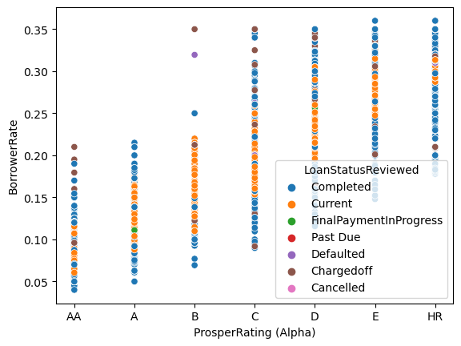

```python
#Checking the loan status of borrowers with high risk and high rates
sb.scatterplot(data=df1, x='ProsperRating (Alpha)', y='BorrowerRate',hue='LoanStatusReviewed');

#The loan status are majorly betweeen completed and current, this is probaby attributed to the larger number of the
#dataset being completed or current
```

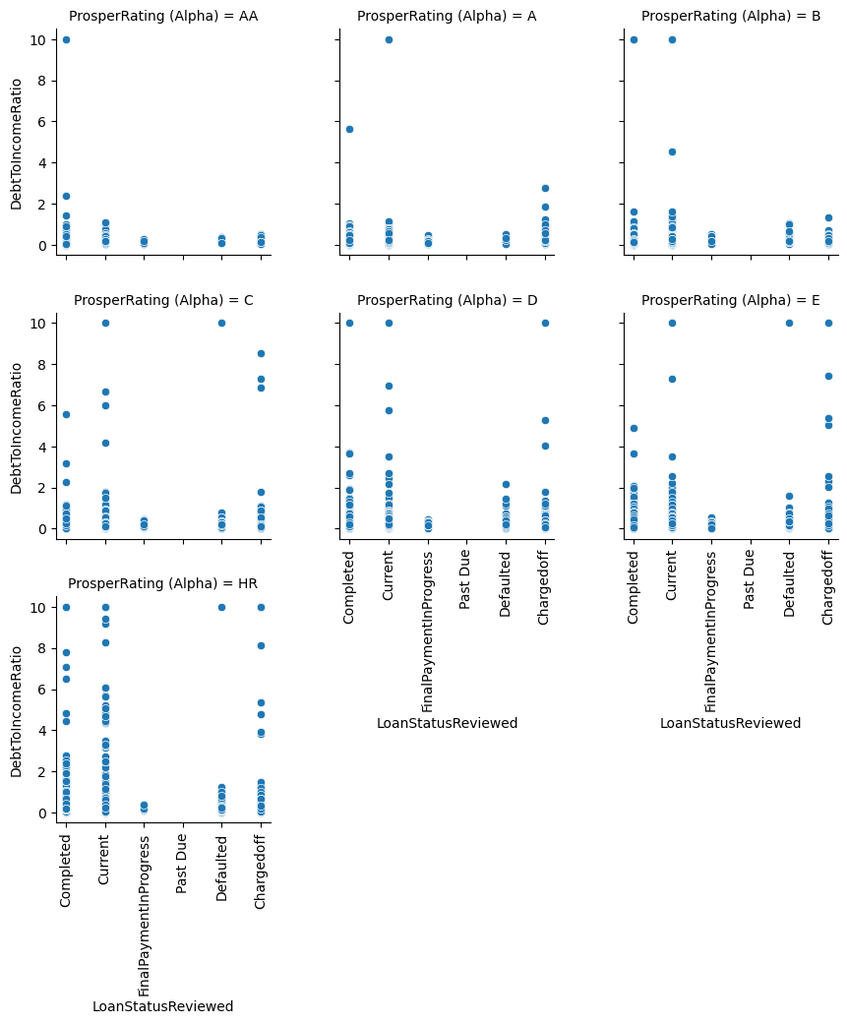

```python
#Relationship between rating, DebtToIncomeRatio and loan status
g = sb.FacetGrid(data=df1, col= 'ProsperRating (Alpha)',col_wrap=3)
g.map(sb.scatterplot,'LoanStatusReviewed', 'DebtToIncomeRatio')
xtick_rot()


#A good number of poor ratings had high debt to income ratio and are current or have completed their loans
#Few numbers of high risk and high debt to income ratio had their loans charged off or defaulted
#People with good ratings majorly had low DTIR and majority are current on their loan or have completed it

#I want to know if high risk payments complete their payments most times or default
```

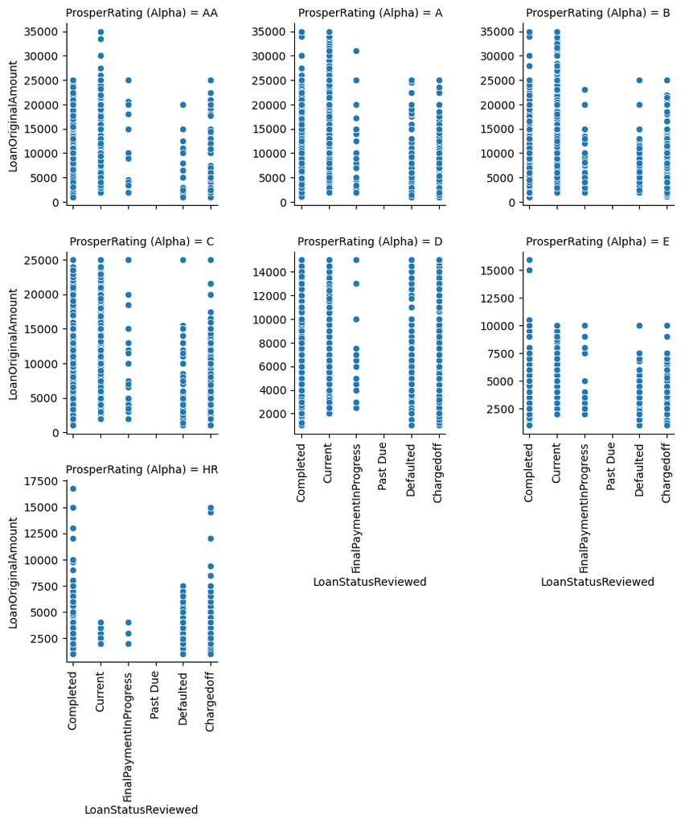

```python
#Relationship between rating, Loan amount and loan status
g = sb.FacetGrid(data=df1, col= 'ProsperRating (Alpha)',col_wrap=3,sharey=False)
g.map(sb.scatterplot,'LoanStatusReviewed', 'LoanOriginalAmount')
xtick_rot()

#Tangible proportions of payments were charged off and defaulted regardless of the risk ratings
```

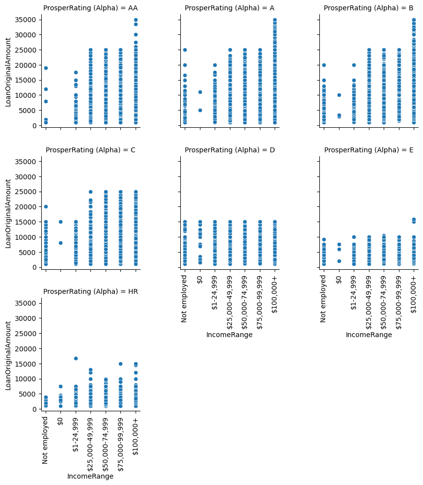

```python
#Relationship between rating, Loan amount and income range
g = sb.FacetGrid(data=df1, col= 'ProsperRating (Alpha)',col_wrap=3)
g.map(sb.scatterplot,'IncomeRange', 'LoanOriginalAmount')
xtick_rot()

#all ratings have high prorpotion pf income range greater than 25,000
#Good ratings i.e AA TO C with high loan amount have a good number having high income range
```

## 2. Observation 3

i) The higher the term the higher the loan amount -- Compare with borrower rates, let's see if higher amounts and terms have high or low rates

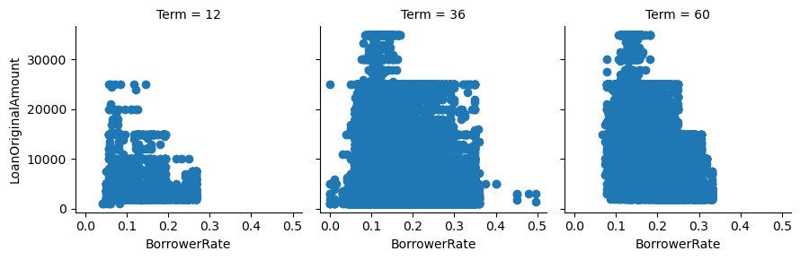

```python
g = sb.FacetGrid(data=df1,col='Term')
g.map(plt.scatter,'BorrowerRate','LoanOriginalAmount')

#Borrowers with higher loan amounts fall have a lower rate in both the 36 and 60 months ter
#The 12 months term do not have as high amounts as the other term
#People with really high rates i.e 40% to 50% have low loan amounts and fall in the 36 months term,unique cases?
```

```python
#Looking at the outliers in 36 month term .e. very high rates and low loan amount
unique_case = df1[(df1['BorrowerRate'] >= 0.4)  & (df1['LoanOriginalAmount'] < 10000)]
unique_case

#only one person completed their payment, all other were either charged off or defaulted
#the only person that completed tthe loan has the lowest debt to income ratio of them all and the lowest loan amount
#They all had no listing category,occupation or employment status filled
#All were before the introduction of the rating system
```

|  | LoanKey | ListingCreationDate | LoanStatus | Term | BorrowerRate | ProsperRating (Alpha) | ListingCategory (numeric) | BorrowerState | EmploymentStatus | Occupation | IsBorrowerHomeowner | DebtToIncomeRatio | IncomeRange | IncomeVerifiable | LoanOriginalAmount | Recommendations | LoanStatusReviewed |
| --- | --- | --- | --- | --- | --- | --- | --- | --- | --- | --- | --- | --- | --- | --- | --- | --- | --- |
| 14160 | 3B463365305395676533B86 | 2006-03-18 12:52:18.843 | Chargedoff | 36 | 0.4000 | NaN | 0 | NaN | NaN | NaN | False | 0.18002 | Not displayed | True | 5000 | 0 | Chargedoff |
| 18326 | EABB336549566056637F106 | 2006-03-11 15:43:45.393 | Defaulted | 36 | 0.4500 | NaN | 0 | NaN | NaN | NaN | False | 0.10252 | Not displayed | True | 3000 | 0 | Defaulted |
| 22195 | C6523364419622003354C47 | 2006-03-12 13:44:15.060 | Chargedoff | 36 | 0.4500 | NaN | 0 | NaN | NaN | NaN | False | 0.35430 | Not displayed | True | 1789 | 0 | Chargedoff |
| 36018 | 08423365150780340A7980C | 2006-02-23 13:57:02.087 | Completed | 36 | 0.4975 | NaN | 0 | NaN | NaN | NaN | False | 0.02852 | Not displayed | True | 1500 | 0 | Completed |
| 56761 | 51A6336556683591380DA02 | 2006-03-16 19:30:16.753 | Defaulted | 36 | 0.4975 | NaN | 0 | NaN | NaN | NaN | False | 0.03909 | Not displayed | False | 3000 | 0 | Defaulted |
| 82043 | 66E93364923759158FBB4B6 | 2006-03-02 19:00:17.593 | Defaulted | 36 | 0.4800 | NaN | 0 | NaN | NaN | NaN | False | 0.10021 | Not displayed | True | 3000 | 0 | Defaulted |
| 95035 | 7A453364810866496CAA53F | 2006-03-11 16:00:10.990 | Defaulted | 36 | 0.4000 | NaN | 0 | NaN | NaN | NaN | False | 0.10773 | Not displayed | True | 5000 | 0 | Defaulted |
| 103973 | CB5D3366317516824071A4F | 2006-03-06 22:36:53.753 | Defaulted | 36 | 0.4500 | NaN | 0 | NaN | NaN | NaN | False | 0.19413 | Not displayed | True | 2800 | 0 | Defaulted |

## 3. Observation 8

--Compare with Rating

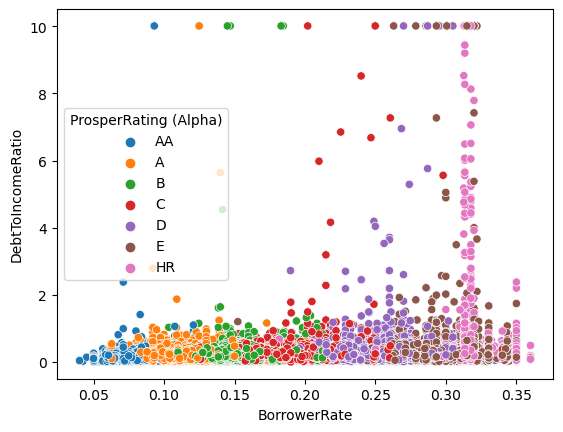

```python
sb.scatterplot(data=df1,x='BorrowerRate',y='DebtToIncomeRatio',hue='ProsperRating (Alpha)')

#Ratings from D to HR have a higher rate and Debt to Income Ratio
```

### Observations from Multivariate Visualization

1.The loan status are majorly betweeen completed and current, this is probaby attributed to the larger number of the dataset being completed or current Tangible proportions of payments were charged off and defaulted regardless of the risk ratings

1. Borrowers with higher loan amounts fall have a lower rate in both the 36 and 60 months ter The 12 months term do not have as high amounts as the other term People with really high rates i.e 40% to 50% have low loan amounts and fall in the 36 months term,unique cases?

A good number of poor ratings had high debt to income ratio and are current or have completed their loans. Few numbers of high risk and high debt to income ratio had their loans charged off or defaulted. People with good ratings majorly had low DTIR and majority are current on their loan or have completed it

Only one person completed their payment, all other were either charged off or defaulted The only person that completed tthe loan has the lowest debt to income ratio of them all and the lowest loan amount They all had no listing category,occupation or employment status filled All were before the introduction of the rating system

1. Ratings from D to HR have a higher rate and Debt to Income Ratio